# Activity Quality Class Prediction

Vince Force

28 janvier 2018

## Executive summary

The goal of this project will be to use data from accelerometers on the belt, forearm, arm, and dumbell of 6 participants. They were asked to perform barbell lifts correctly and incorrectly in 5 different ways. We fill fit various models to get a prediction on a validation dataset where the classe information is not provided.

The overall approach is to use cross-validation (split the data in pml-training.csv into training and testing data sets) to select / tune various models.

In order to obtain the best prediction, we perform a benchmark of various algorithms, comparing accuracy, execution time and “correct” prediction on validation set. Will the winner be Random Forest, as often ?

Finally, we use the data collected during the benchmark to form ensembling models. Will there be new winner ?

## Data

After loading the trainig and testing datasets, we perform an exploratory analysis on the training dataset.

We take the data in pml-testing.csv as validation data.

We will split the data in pml-training.csv into training and testing data sets, to perform cross-validation.

Finally, the types of predictors are integer, numeric and unordinal factor.

The class column contains 5 values : A, B, C, D, E.

These values are unordered, we are in the case of classification with multinomial outcome (not ordinal factor).

### Loading

```r
analysis <- read.csv("pml-training.csv")
validation <- read.csv("pml-testing.csv")
dimAnal <- dim(analysis)
dimValid <- dim(validation)
```

The prediction dataset has 160 columns and 19622 rows. The validation dataset has 160 columns and 20 rows.

### Cleaning

A quick look at validation dataset shows that many columns have only NA values. These columns are to be removed in all datasets (training, testing, validation), as the can not be predictors in the validation case.

The columns which are not relevant to form a model of the practice are to be deleted. We discard the 7 first columns except user_name (maybe the information could be useful for validation in case of repetitive behaviour by user) and num_window.

The last column of validation dataset is the line number, to be deleted.

```r
cleanData <- function(analysis, validation) {
    table(complete.cases(analysis))
    table(complete.cases(validation))
    indColsNA <- sapply(colnames(validation),
        function(cn) {sum(is.na(validation[, cn])) == dim(validation)[1]})
    analysis <- analysis[, !indColsNA]
    validation <- validation[, !indColsNA]
    table(complete.cases(analysis))
    table(complete.cases(validation))
    analysis <- analysis[,-c(1, 3, 4, 5, 6)]
    validation <- validation[,-c(1, 3, 4, 5, 6, dim(validation)[2])]
    dim(analysis); dim(validation)
    return(list(analysis, validation))
}

cD <- cleanData(analysis, validation)
analysis <- cD[[1]]
validation <- cD[[2]]
dimAnal <- dim(analysis)
dimValid <- dim(validation)
```

We get, after data cleaning, 54 features for one outcome to predict, without any NA value.

### Exploratory analysis

We try to find correlations between the features.

These are linked to the 4 captors used for original measures. Let us group the analysis by captor.

We draw a correlation plot for each of the 10 couples of captors. On the first plot, the diagonal of the correlation matrix. On the second plot, the other items, from the diagonal to the corner (of the correlation matrix).

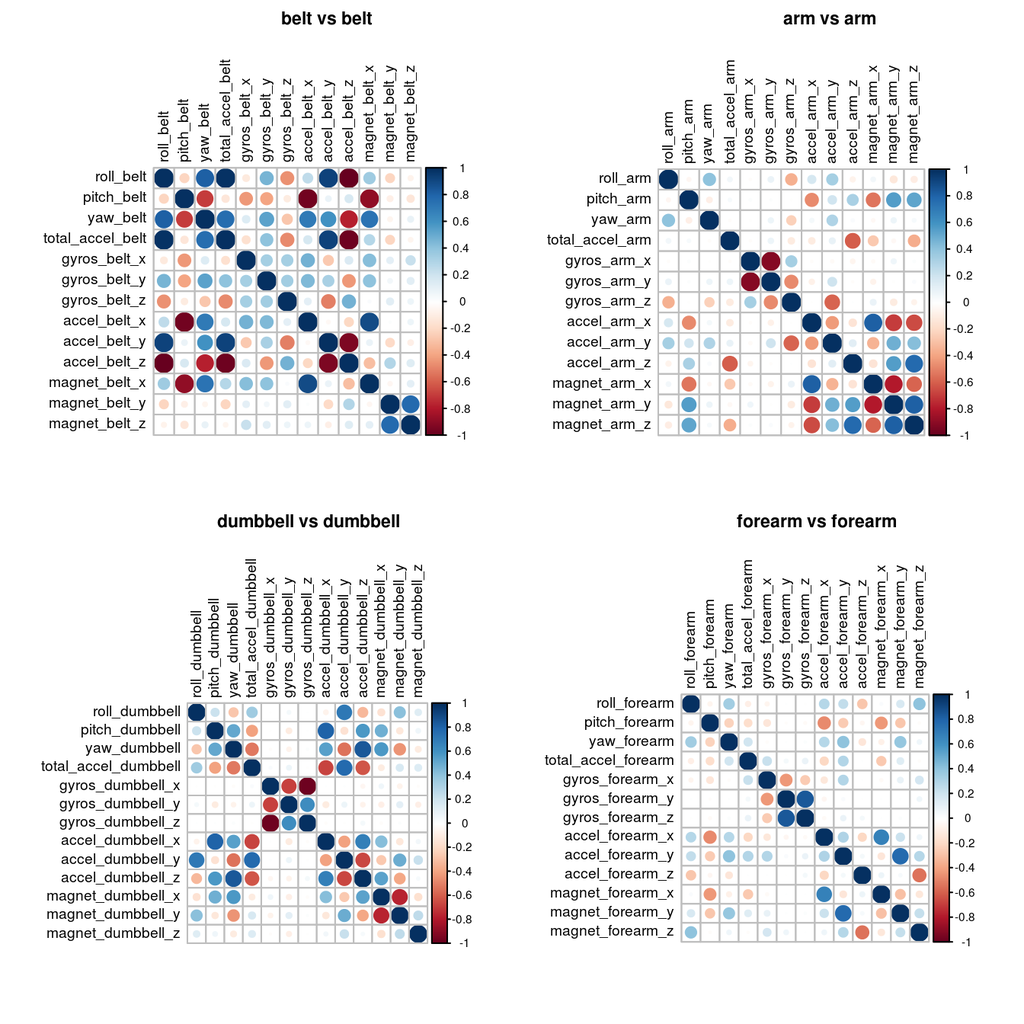

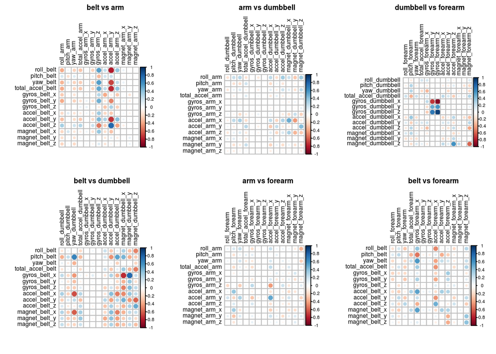

Nice. But a bit complicated handle with.

Fortunately, we have many other approaches for classification !

## Training and testing datasets

For performing cross-validation, we split the original training dataset in two datasets, with a proportion of 70% for the resulting training dataset.

The original testing dataset will be used for validation.

The original training dataset has been splitted into a (new) training dataset (13737 rows) and a testing dataset (5885 rows).

## Analysis

Algoritms provided with R have various implementations (on train command usage, or objects returned, …). The benchmark code has to deal with this.

### Benchmark of various models

Now we launch the benchmark… Fortunately, if you read the HTML document, you don’t have to wait too long !

```
## [1] ">> >> >> Start model - Multinom - 2018-01-28 23:26:11"
## [1] ">> >> >> Start model - Multinom with preprocess scale - 2018-01-28 23:26:32"
## [1] ">> >> >> Start model - Multinom with preprocess pca - 2018-01-28 23:26:44"
## [1] ">> >> >> Start model - Multinom with preprocess range - 2018-01-28 23:26:51"
## [1] ">> >> >> Start model - Linear Discriminant Analysis - 2018-01-28 23:27:00"
## [1] ">> >> >> Start model - Rpart - 2018-01-28 23:27:16"
## [1] ">> >> >> Start model - Rpart with preprocess pca - 2018-01-28 23:27:20"
## [1] ">> >> >> Start model - Rpart tuned (minsplit = 30, minbucket = 10, cp = 0.0001) - 2018-01-28 23:27:25"
## [1] ">> >> >> Start model - GBM - 2018-01-28 23:27:30"
## [1] ">> >> >> Start model - GBM with interaction.depth = 1, shrinkage = 0.1 - 2018-01-28 23:27:42"
## [1] ">> >> >> Start model - GBM with interaction.depth = 2, shrinkage = 0.1 - 2018-01-28 23:27:53"
## [1] ">> >> >> Start model - GBM with interaction.depth = 3, shrinkage = 0.1 - 2018-01-28 23:28:13"
## [1] ">> >> >> Start model - GBM with interaction.depth = 4, shrinkage = 0.1 - 2018-01-28 23:28:40"
## [1] ">> >> >> Start model - GBM with interaction.depth = 6, shrinkage = 0.1 - 2018-01-28 23:29:16"
## [1] ">> >> >> Start model - GBM with interaction.depth = 7, shrinkage = 0.1 - 2018-01-28 23:30:04"
## [1] ">> >> >> Start model - GBM with interaction.depth = 10, shrinkage = 0.1 - 2018-01-28 23:31:05"
## [1] ">> >> >> Start model - Treebag - 2018-01-28 23:32:28"
## [1] ">> >> >> Start model - Bagging - 2018-01-28 23:43:36"
## [1] ">> >> >> Start model - Boosting with boos = FALSE, mfinal = 100, coeflearn = 'Zhu' - 2018-01-28 23:52:58"
## [1] ">> >> >> Start model - Support Vector Machines linear kernel - 2018-01-29 00:07:36"
## [1] ">> >> >> Start model - Support Vector Machines radial kernel - 2018-01-29 00:09:01"
## [1] ">> >> >> Start model - Support Vector Machines kernel polynomial (3) - 2018-01-29 00:10:35"
## [1] ">> >> >> Start model - Support Vector Machines kernel polynomial (2) - 2018-01-29 00:11:58"
## [1] ">> >> >> Start model - Random forest - 2018-01-29 00:13:32"
```

### Benchmark of various models : results

And here are the first results. The execution (st.elps) time is given by system.time() method. Other times are computed, but not showmn on the final results for presentation convenience. We could have found important variations in cpu usage, to be taken into account for a more realistic benchmark.

The models used in the benchmark are returned, for further investigation and plotting purposes.

The table below shows modles benchmark results, classed by Accuracy in descending order.

The Random Forest algorithm is the last tested (**Model_24**).

|  | Name | Accuracy | st.elps | p1 | p2 | p3 | p4 | p5 | p6 | p7 | p8 | p9 | p10 | p11 | p12 | p13 | p14 | p15 | p16 | p17 | p18 | p19 | p20 | errV |
| --- | --- | --- | --- | --- | --- | --- | --- | --- | --- | --- | --- | --- | --- | --- | --- | --- | --- | --- | --- | --- | --- | --- | --- | --- |
| 16 | Model_16 | 0.9983 | 82.69 | B | A | B | A | A | E | D | B | A | A | B | C | B | A | E | E | A | B | B | B | 0 |
| 19 | Model_19 | 0.9981 | 877.75 | B | A | B | A | A | E | D | B | A | A | B | C | B | A | E | E | A | B | B | B | 0 |
| 17 | Model_17 | 0.9971 | 667.53 | B | A | B | A | A | E | D | B | A | A | B | C | B | A | E | E | A | B | B | B | 0 |
| 24 | Model_24 | 0.9968 | 60.49 | B | A | B | A | A | E | D | B | A | A | B | C | B | A | E | E | A | B | B | B | 0 |
| 15 | Model_15 | 0.9961 | 60.89 | B | A | B | A | A | E | D | B | A | A | B | C | B | A | E | E | A | B | B | B | 0 |
| 14 | Model_14 | 0.9942 | 47.58 | B | A | B | A | A | E | D | B | A | A | B | C | B | A | E | E | A | B | B | B | 0 |
| 13 | Model_13 | 0.9818 | 35.78 | B | A | B | A | A | E | D | B | A | A | B | C | B | A | E | E | A | B | B | B | 0 |
| 12 | Model_12 | 0.9665 | 26.81 | B | A | B | A | A | E | D | B | A | A | B | C | B | A | E | E | A | B | B | B | 0 |
| 8 | Model_8 | 0.9546 | 5.21 | B | A | B | A | A | E | D | A | A | A | B | C | B | A | E | E | A | B | B | B | 1 |
| 21 | Model_21 | 0.9388 | 93.77 | B | A | A | A | A | E | D | B | A | A | B | C | B | A | E | E | A | B | B | B | 1 |
| 11 | Model_11 | 0.9361 | 19.52 | B | A | B | A | A | E | D | B | A | A | B | C | B | A | E | E | A | B | B | B | 0 |
| 22 | Model_22 | 0.9259 | 82.64 | B | A | A | A | A | E | D | B | A | A | B | C | B | A | E | E | A | B | B | B | 1 |
| 23 | Model_23 | 0.9060 | 93.46 | B | A | A | A | A | E | D | B | A | A | B | C | B | A | E | E | A | B | B | B | 1 |
| 10 | Model_10 | 0.8214 | 11.53 | D | A | A | A | A | E | D | D | A | A | B | C | B | A | E | E | A | B | A | B | 4 |
| 18 | Model_18 | 0.8192 | 561.35 | B | A | B | A | A | C | D | D | A | A | C | C | C | A | E | E | A | A | B | B | 5 |
| 20 | Model_20 | 0.8007 | 84.51 | C | A | B | C | A | E | D | D | A | A | B | A | B | A | E | E | A | B | B | B | 4 |
| 6 | Model_6 | 0.7567 | 3.61 | B | A | E | A | A | C | D | D | A | A | C | C | C | A | E | D | A | A | A | B | 8 |
| 4 | Model_4 | 0.7432 | 8.55 | C | A | B | A | C | E | D | E | A | A | C | A | B | A | E | E | A | B | B | B | 5 |
| 5 | Model_5 | 0.7380 | 15.88 | B | A | B | A | A | C | D | D | A | A | D | A | B | A | B | A | A | B | B | B | 6 |
| 2 | Model_2 | 0.7334 | 10.91 | C | B | B | A | A | E | D | D | A | A | C | C | E | A | E | E | A | B | B | B | 5 |
| 1 | Model_1 | 0.6805 | 21.36 | B | A | B | A | A | E | D | D | A | A | B | C | E | A | E | A | A | B | A | B | 4 |
| 3 | Model_3 | 0.5324 | 7.33 | B | A | A | A | A | C | D | D | A | C | B | A | E | A | E | B | A | B | A | B | 8 |
| 9 | Model_9 | 0.5217 | 11.16 | D | A | A | C | C | C | D | D | A | C | A | A | C | A | A | A | C | D | D | A | 16 |
| 7 | Model_7 | 0.5135 | 4.58 | A | A | B | A | B | C | D | A | A | A | A | C | E | A | E | B | A | E | A | B | 9 |

| Name | Algo | Accuracy | st.elps | errV | rankAcc |
| --- | --- | --- | --- | --- | --- |
| Model_1 | Multinom | 0.6805 | 21.36 | 4 | 16 |
| Model_2 | Multinom with preprocess scale | 0.7334 | 10.91 | 5 | 19 |
| Model_3 | Multinom with preprocess pca | 0.5324 | 7.33 | 8 | 17 |
| Model_4 | Multinom with preprocess range | 0.7432 | 8.55 | 5 | 24 |
| Model_5 | Linear Discriminant Analysis | 0.7380 | 15.88 | 6 | 15 |
| Model_6 | Rpart | 0.7567 | 3.61 | 8 | 14 |
| Model_7 | Rpart with preprocess pca | 0.5135 | 4.58 | 9 | 13 |
| Model_8 | Rpart tuned (minsplit = 30, minbucket = 10, cp = 0.0001) | 0.9546 | 5.21 | 1 | 12 |
| Model_9 | GBM | 0.5217 | 11.16 | 16 | 8 |
| Model_10 | GBM with interaction.depth = 1, shrinkage = 0.1 | 0.8214 | 11.53 | 4 | 21 |
| Model_11 | GBM with interaction.depth = 2, shrinkage = 0.1 | 0.9361 | 19.52 | 0 | 11 |
| Model_12 | GBM with interaction.depth = 3, shrinkage = 0.1 | 0.9665 | 26.81 | 0 | 22 |
| Model_13 | GBM with interaction.depth = 4, shrinkage = 0.1 | 0.9818 | 35.78 | 0 | 23 |
| Model_14 | GBM with interaction.depth = 6, shrinkage = 0.1 | 0.9942 | 47.58 | 0 | 10 |
| Model_15 | GBM with interaction.depth = 7, shrinkage = 0.1 | 0.9961 | 60.89 | 0 | 18 |
| Model_16 | GBM with interaction.depth = 10, shrinkage = 0.1 | 0.9983 | 82.69 | 0 | 20 |
| Model_17 | Treebag | 0.9971 | 667.53 | 0 | 6 |
| Model_18 | Bagging | 0.8192 | 561.35 | 5 | 4 |
| Model_19 | Boosting with boos = FALSE, mfinal = 100, coeflearn = ‘Zhu’ | 0.9981 | 877.75 | 0 | 5 |
| Model_20 | Support Vector Machines linear kernel | 0.8007 | 84.51 | 4 | 2 |
| Model_21 | Support Vector Machines radial kernel | 0.9388 | 93.77 | 1 | 1 |
| Model_22 | Support Vector Machines kernel polynomial (3) | 0.9259 | 82.64 | 1 | 3 |
| Model_23 | Support Vector Machines kernel polynomial (2) | 0.9060 | 93.46 | 1 | 9 |
| Model_24 | Random forest | 0.9968 | 60.49 | 0 | 7 |

On accuracy score, Random Forest is beaten, and there are challengers with close execution time.

We have many models with “0 errors” (all with same prediction as rf) on validation dataset.

But what of global scores when combining these models?

### Combining models according to benchmark

We try several manners to combine the models, using (except for one case) a classification of the predictions (A, B, C, D, E) of individual models as predictors (with a tuned rpart). The predictions returned by the benchmark function are used for saving computation time.

And here are the final results.

[output not shown]

|  | Name | Accuracy | st.elps | p1 | p2 | p3 | p4 | p5 | p6 | p7 | p8 | p9 | p10 | p11 | p12 | p13 | p14 | p15 | p16 | p17 | p18 | p19 | p20 | errV |
| --- | --- | --- | --- | --- | --- | --- | --- | --- | --- | --- | --- | --- | --- | --- | --- | --- | --- | --- | --- | --- | --- | --- | --- | --- |
| 1 | Comb_1 | 0.8651 | 23.75 | B | A | A | A | A | E | D | D | A | A | C | C | B | A | E | E | A | B | A | B | 4 |
| 2 | Comb_2 | 0.9752 | 118.54 | B | A | B | A | A | E | D | B | A | A | B | C | B | A | E | E | A | B | B | B | 0 |
| 3 | Comb_3 | 0.9740 | 51.59 | B | A | B | A | A | E | D | B | A | A | B | C | B | A | E | E | A | B | B | B | 0 |
| 4 | Comb_4 | 0.9828 | 22.95 | B | A | B | A | A | E | D | D | A | A | B | C | B | A | E | E | A | B | B | B | 1 |
| 5 | Comb_5 | 0.9830 | 52.56 | B | A | B | A | A | E | D | B | A | A | B | C | B | A | E | E | A | B | B | B | 0 |
| 6 | Comb_6 | 0.9670 | 48.50 | B | A | B | A | A | E | D | B | A | A | B | C | B | A | E | E | A | B | B | B | 0 |
| 7 | Comb_7 | 0.9992 | 1749.38 | B | A | B | A | A | E | D | B | A | A | B | C | B | A | E | E | A | B | B | B | 0 |
| 24 | RF | 0.9968 | 60.49 | B | A | B | A | A | E | D | B | A | A | B | C | B | A | E | E | A | B | B | B | 0 |

Comments:

Finally, on this specific case (with this value of set.seed), the model GBM with interaction.depth = 6 stays the best tradeoff accuracy / execution time.

## Conclusion

A well tuned, step by step constructed model can beat the champions.

Additional investigations could be performed :

- Try to analyse why some validation cases are quite easy to predict, and some are not (especially N° 8)
- Try to reduce the number of features considering their correlation strength, even if pca preprocessing has given deceptive results, especially for lowering execution delays of time consuming methods (bagging, treebag), but without lowering their accuracy
- Try other types of algorithms (e.g. quadratic discriminant analysis), to have more models of different types to combine
- Try to separate data by user (checking the resulting number of rows for each set), analyse each set separately, and use user_name information in validation dataset for selecting the appropriate model; but the purpose was to be useful for anyone after collecting a few data from volunteers, and this approach might be useful just to compare volunteers behaviours

## Appendix

### Plots for some of the unitary models

From the models returned by the benchmark phase, we can use plot functions or summary function to draw model properties.

#### Linear Discriminant Analysis

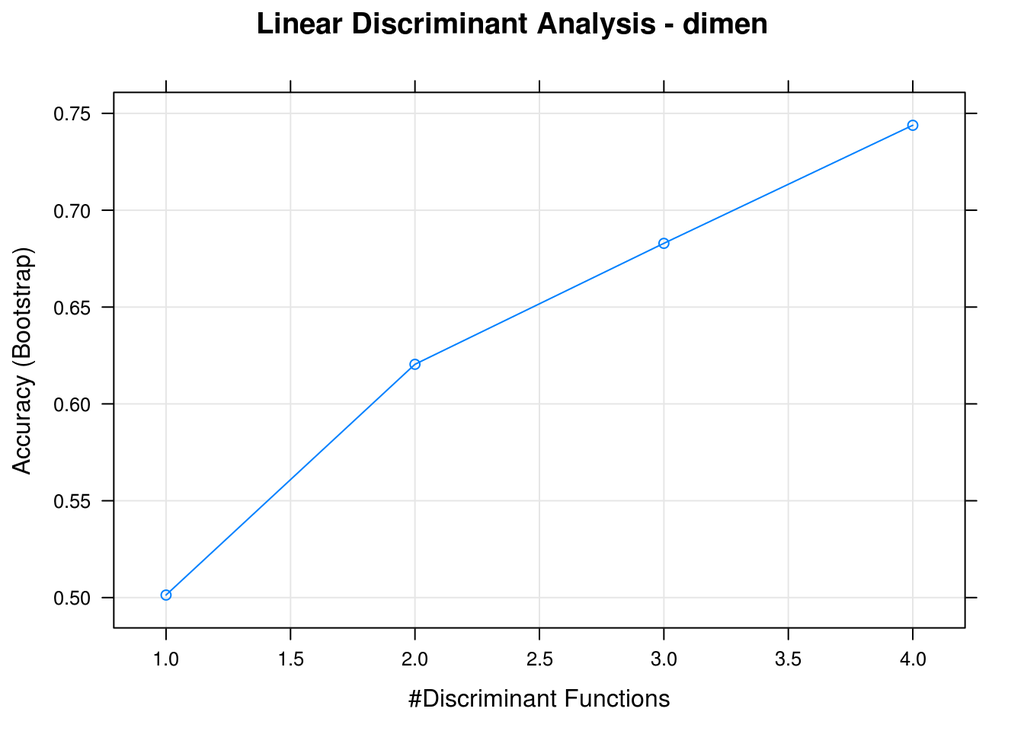

```r
par(mfrow = c(1, 1))
mdl <- bm$modelFits[["Linear Discriminant Analysis"]]
plot(mdl, main = "Linear Discriminant Analysis - dimen")
```

#### Rpart

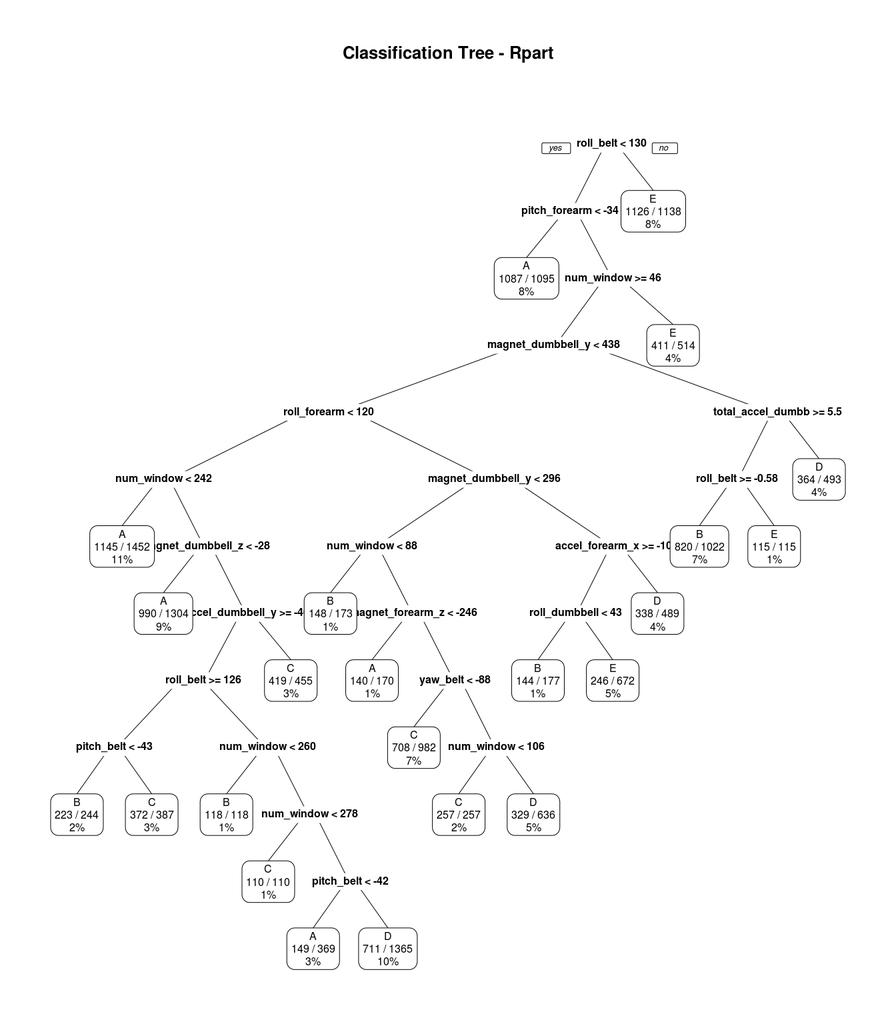

```r
par(mfrow = c(1, 1))
mdl <- bm$modelFits[["Rpart"]]
prp(mdl, main="Classification Tree - Rpart", extra=102, cex=0.5)
```

#### GBM with interaction.depth = c(1, 10)

Note the behaviour of num_window feature.

```r
par(mfrow = c(1, 2))
mdl <- bm$modelFits[["GBM with interaction.depth = 1, shrinkage = 0.1"]]
summary(mdl, las = 1, cex.lab = 0.6, cex.axis = 0.6, cex = 0.6,
        main = "Importance of features - GBM 1")
```

```
##                                       var    rel.inf
## roll_belt                       roll_belt 31.4014404
## pitch_forearm               pitch_forearm 18.1460183
## magnet_dumbbell_y       magnet_dumbbell_y  7.4431031
## num_window                     num_window  6.1420212
## yaw_belt                         yaw_belt  5.2987529
## roll_forearm                 roll_forearm  3.8580401
## accel_forearm_x           accel_forearm_x  3.8166392
## magnet_dumbbell_z       magnet_dumbbell_z  3.5503580
## gyros_dumbbell_y         gyros_dumbbell_y  3.1604749
## roll_dumbbell               roll_dumbbell  3.0277749
## gyros_belt_z                 gyros_belt_z  2.6305395
## pitch_belt                     pitch_belt  1.8565842
## magnet_belt_z               magnet_belt_z  1.7686997
## magnet_belt_y               magnet_belt_y  1.4290397
## magnet_arm_x                 magnet_arm_x  1.2638939
## accel_dumbbell_y         accel_dumbbell_y  1.2396220
## magnet_dumbbell_x       magnet_dumbbell_x  1.2331284
## yaw_arm                           yaw_arm  1.1887564
## accel_dumbbell_x         accel_dumbbell_x  0.5798438
## pitch_dumbbell             pitch_dumbbell  0.5148593
## magnet_arm_z                 magnet_arm_z  0.4504101
## user_name                       user_name  0.0000000
## total_accel_belt         total_accel_belt  0.0000000
## gyros_belt_x                 gyros_belt_x  0.0000000
## gyros_belt_y                 gyros_belt_y  0.0000000
## accel_belt_x                 accel_belt_x  0.0000000
## accel_belt_y                 accel_belt_y  0.0000000
## accel_belt_z                 accel_belt_z  0.0000000
## magnet_belt_x               magnet_belt_x  0.0000000
## roll_arm                         roll_arm  0.0000000
## pitch_arm                       pitch_arm  0.0000000
## total_accel_arm           total_accel_arm  0.0000000
## gyros_arm_x                   gyros_arm_x  0.0000000
## gyros_arm_y                   gyros_arm_y  0.0000000
## gyros_arm_z                   gyros_arm_z  0.0000000
## accel_arm_x                   accel_arm_x  0.0000000
## accel_arm_y                   accel_arm_y  0.0000000
## accel_arm_z                   accel_arm_z  0.0000000
## magnet_arm_y                 magnet_arm_y  0.0000000
## yaw_dumbbell                 yaw_dumbbell  0.0000000
## total_accel_dumbbell total_accel_dumbbell  0.0000000
## gyros_dumbbell_x         gyros_dumbbell_x  0.0000000
## gyros_dumbbell_z         gyros_dumbbell_z  0.0000000
## accel_dumbbell_z         accel_dumbbell_z  0.0000000
## yaw_forearm                   yaw_forearm  0.0000000
## total_accel_forearm   total_accel_forearm  0.0000000
## gyros_forearm_x           gyros_forearm_x  0.0000000
## gyros_forearm_y           gyros_forearm_y  0.0000000
## gyros_forearm_z           gyros_forearm_z  0.0000000
## accel_forearm_y           accel_forearm_y  0.0000000
## accel_forearm_z           accel_forearm_z  0.0000000
## magnet_forearm_x         magnet_forearm_x  0.0000000
## magnet_forearm_y         magnet_forearm_y  0.0000000
## magnet_forearm_z         magnet_forearm_z  0.0000000
```

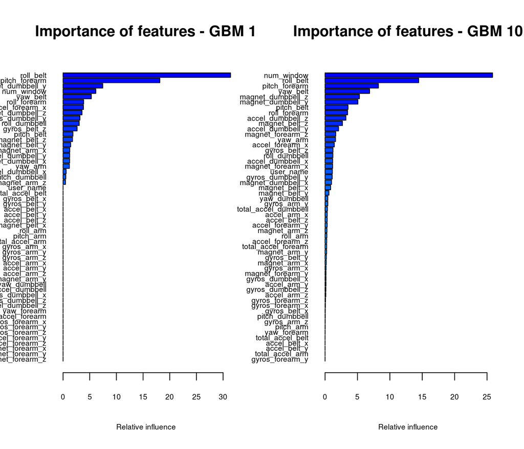

```
##                                       var     rel.inf
## num_window                     num_window 25.85243676
## roll_belt                       roll_belt 14.44962900
## pitch_forearm               pitch_forearm  8.23407605
## yaw_belt                         yaw_belt  6.87471940
## magnet_dumbbell_z       magnet_dumbbell_z  5.30366884
## magnet_dumbbell_y       magnet_dumbbell_y  5.06591003
## pitch_belt                     pitch_belt  3.54573252
## roll_forearm                 roll_forearm  3.47663704
## accel_dumbbell_z         accel_dumbbell_z  3.21864305
## magnet_belt_z               magnet_belt_z  2.68204161
## accel_dumbbell_y         accel_dumbbell_y  2.08631990
## magnet_forearm_z         magnet_forearm_z  1.64915085
## yaw_arm                           yaw_arm  1.61478543
## accel_forearm_x           accel_forearm_x  1.42523044
## gyros_belt_z                 gyros_belt_z  1.22412177
## roll_dumbbell               roll_dumbbell  1.20829369
## accel_dumbbell_x         accel_dumbbell_x  1.17655950
## magnet_forearm_x         magnet_forearm_x  1.17146169
## user_name                       user_name  1.12891173
## gyros_dumbbell_y         gyros_dumbbell_y  1.10502464
## magnet_dumbbell_x       magnet_dumbbell_x  0.99896225
## magnet_belt_x               magnet_belt_x  0.85798462
## magnet_belt_y               magnet_belt_y  0.59591349
## yaw_dumbbell                 yaw_dumbbell  0.42542766
## gyros_arm_y                   gyros_arm_y  0.42415807
## total_accel_dumbbell total_accel_dumbbell  0.36384358
## accel_arm_x                   accel_arm_x  0.33993762
## accel_belt_z                 accel_belt_z  0.33312331
## accel_forearm_y           accel_forearm_y  0.33117384
## magnet_arm_z                 magnet_arm_z  0.29640922
## roll_arm                         roll_arm  0.28568247
## accel_forearm_z           accel_forearm_z  0.26367492
## total_accel_forearm   total_accel_forearm  0.25808236
## magnet_arm_y                 magnet_arm_y  0.24664735
## gyros_belt_y                 gyros_belt_y  0.20378981
## magnet_arm_x                 magnet_arm_x  0.18485667
## gyros_arm_x                   gyros_arm_x  0.15942950
## magnet_forearm_y         magnet_forearm_y  0.14592146
## gyros_dumbbell_x         gyros_dumbbell_x  0.14375162
## accel_arm_y                   accel_arm_y  0.14002852
## gyros_dumbbell_z         gyros_dumbbell_z  0.12239927
## accel_arm_z                   accel_arm_z  0.11268985
## gyros_forearm_z           gyros_forearm_z  0.07206054
## gyros_forearm_x           gyros_forearm_x  0.05743645
## gyros_belt_x                 gyros_belt_x  0.03746364
## pitch_dumbbell             pitch_dumbbell  0.03571299
## gyros_arm_z                   gyros_arm_z  0.02757885
## pitch_arm                       pitch_arm  0.02589918
## yaw_forearm                   yaw_forearm  0.01660692
## total_accel_belt         total_accel_belt  0.00000000
## accel_belt_x                 accel_belt_x  0.00000000
## accel_belt_y                 accel_belt_y  0.00000000
## total_accel_arm           total_accel_arm  0.00000000
## gyros_forearm_y           gyros_forearm_y  0.00000000
```

```r
mdl <- bm$modelFits[["GBM with interaction.depth = 10, shrinkage = 0.1"]]
summary(mdl, las = 1, cex.lab = 0.6, cex.axis = 0.6, cex = 0.6,
        main = "Importance of features - GBM 10")
```

#### Random Forest

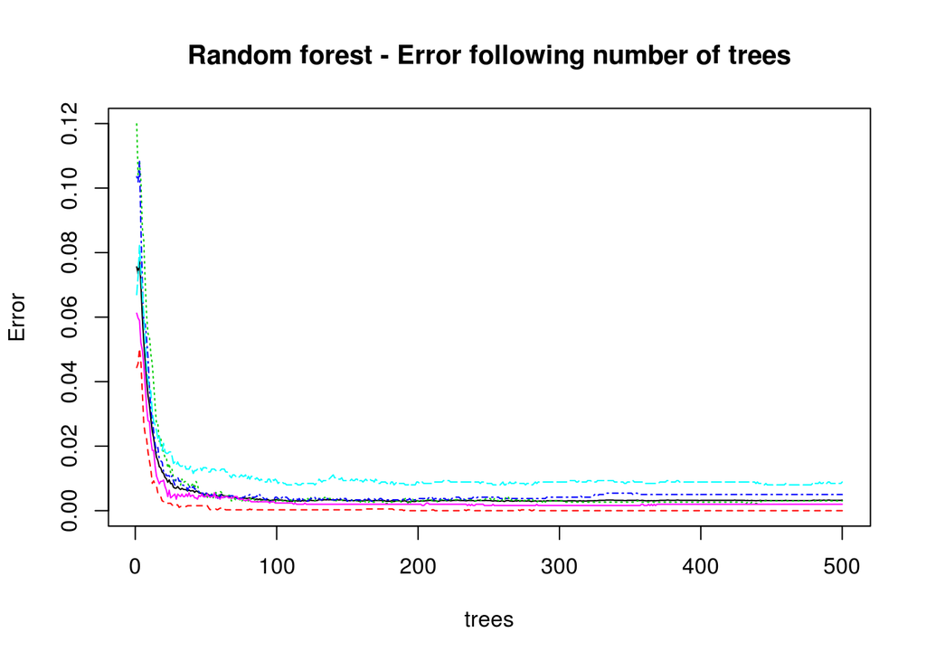

```r
par(mfrow = c(1, 1))
mdl <- bm$modelFits[["Random forest"]]
plot(mdl, main = "Random forest - Error following number of trees")
```

### R code

The follwing chunks of code were not displayed in the report for an easier reading.

Feel free to use and modify this code for your own future analysis.

#### data-explore

```r
drawCorrPlot <- function(x, y = NULL, title = "", mar) {
    if (is.null(y)) {cm <- cor(x)}
    else {cm <- cor(x, y)}
    corrplot(cm, method="circle", tl.col = "black", title = title,
             mar = mar, cl.ratio = 0.25)
}

colNamessbycaptor <- function(captor, ds) {
    return(grep(paste("_(", captor, ")", sep = ""), colnames(ds), value = TRUE))
}

anNum <- analysis[, 1:dim(analysis)[2]-1]
anNum <- anNum[-1]
mar <- c(2, 1, 2, 1)
par(oma = c(1, 0, 0, 1), adj = 0.7)
par(mfrow = c(1, 1), cex = 0.5)
# drawCorrPlot(anNum)
captors <- c("belt", "arm", "dumbbell", "forearm")
cNSet <- sapply(captors, colNamessbycaptor, ds = analysis)
par(mfrow = c(2, 2), cex = 0.6)
drawCorrPlot(anNum[, cNSet[, "belt"]], title = "belt vs belt", mar = mar)
drawCorrPlot(anNum[, cNSet[, "arm"]], title = "arm vs arm", mar = mar)
drawCorrPlot(anNum[, cNSet[, "dumbbell"]], title = "dumbbell vs dumbbell", mar = mar)
drawCorrPlot(anNum[, cNSet[, "forearm"]], title = "forearm vs forearm", mar = mar)
```

```r
par(oma = c(1, 0, 0, 0), adj = 0.7)
par(mfrow = c(2, 3), cex = 0.5)
drawCorrPlot(anNum[, cNSet[, "belt"]], anNum[, cNSet[, "arm"]],
             title = "belt vs arm", mar = mar)
drawCorrPlot(anNum[, cNSet[, "arm"]], anNum[, cNSet[, "dumbbell"]],
             title = "arm vs dumbbell", mar = mar)
drawCorrPlot(anNum[, cNSet[, "dumbbell"]], anNum[, cNSet[, "forearm"]],
             title = "dumbbell vs forearm", mar = mar)
drawCorrPlot(anNum[, cNSet[, "belt"]], anNum[, cNSet[, "dumbbell"]],
             title = "belt vs dumbbell", mar = mar)
drawCorrPlot(anNum[, cNSet[, "arm"]], anNum[, cNSet[, "forearm"]],
             title = "arm vs forearm", mar = mar)
drawCorrPlot(anNum[, cNSet[, "belt"]], anNum[, cNSet[, "forearm"]],
             title = "belt vs forearm", mar = mar)
```

#### train-test-dataset

```r
# effSeed <- sample(1:2^15, 1)
# print(sprintf("Seed for session: %s", effSeed))
# set.seed(effSeed)
set.seed(25651)
inTrain <- createDataPartition(analysis$classe, p = 0.7, list = FALSE)
training <- analysis[inTrain,]; testing <- analysis[-inTrain,]
dimTraining <- dim(training); dimTesting <- dim(testing)
```

#### benchmark-functions

```r
accuracy_rate <- function(test, prediction){
    cm <- table(test$classe, prediction)
    acc <- sum(diag(cm)) / sum(cm)
    return(acc)
}

listVals <- function(l) {
    if (class(l) == "list") {
        nv <- unlist(l); nm <- names(nv); lg <- length(nv)
        if (lg != 0) {
            res <- paste(nm[1], nv[1], sep = " = ")
            if (lg >= 2) {
                for (i in 2:lg) {res <- paste(res, paste(nm[i], nv[i], sep = " = "), sep = ", ")}
            }
        }
        else {res = ""}
    }
    else {res <- l}
    return(res)
}

boProcess <- function(prPOpt, trnOpt, prdOpt, fnName, fnOpt, mdlName, cmOpt, tmOpt,
                      training, testing, validation, frml) {
    testProbClassePred <- NULL
    if (is.null(prPOpt)) {
        trainDS <- training
        testDS <- testing
        valDS <- validation
        prPOpt <- "None"
    }
    else {
        preProc <- preProcess(training[,-1], method = prPOpt)
        trainDS <- predict(preProc, training[,-1])
        testDS <- predict(preProc, testing[,-1])
        valDS <- predict(preProc, validation)
    }
    if (is.null(trnOpt)) {
        if (is.null(tmOpt)) {
            mdlFit <- do.call(fnName,
                    append(list(formula = as.formula(frml), data = trainDS), fnOpt),
                           envir = environment())
        }
        else {
            if (is.null(fnOpt)) {
                mdlFit <- train(as.formula(frml), method = tmOpt, data = trainDS)
            }
            else {
                mdlFit <- do.call("train",
                    append(list(form = as.formula(frml), data = trainDS, method = tmOpt),
                           fnOpt))
            }
        }
        trnOpt <- "None"
    }
    else {
        trnCtrl <- do.call("trainControl", trnOpt)
        if (is.null(tmOpt)) {
           mdlFit <- train(as.formula(frml), method = fn, data = trainDS, trnControl = trnCtrl)
        }
        else {
            mdlFit <- train(as.formula(frml), method = tmOpt, data = trainDS,
                            trnControl = trnCtrl)
        }
    }
    if (cmOpt != 0) {
        if (is.null(prdOpt)) {
            if (cmOpt == 3) {
                testClassePred <- predict(mdlFit, testDS)$class
                vP <- predict(mdlFit, valDS)$class
                cm <- confusionMatrix(testClassePred, testDS$classe)
                acc <- round(as.numeric(cm$overall), 4)[1]
            }
            else {
                testProbClassePred <- predict(mdlFit, testDS)
                vPProb <- predict(mdlFit, valDS)
            }
        }
        else {
            testProbClassePred <- do.call("predict", append(list(mdlFit, testDS), prdOpt))
            vPProb <- do.call("predict", append(list(mdlFit, valDS), prdOpt))
        }
        if (cmOpt == 1) {
            testClassePred <- factor(levels(trainDS$classe)[apply(testProbClassePred,
                                                               1, which.max)])
            vP <- as.character(factor(levels(trainDS$classe)[apply(vPProb, 1, which.max)]))
            acc <- round(accuracy_rate(testDS, testClassePred), 4)
        }
        if (cmOpt == 2) {
            testClassePred <- factor(levels(trainDS$classe)[apply(testProbClassePred[, , 1],
                                                               1, which.max)])
            vP <- as.character(factor(levels(trainDS$classe)[apply(vPProb[, , 1],
                                                                   1, which.max)]))
            acc <- round(accuracy_rate(testDS, testClassePred), 4)
        }
    }
    else {
        if (is.null(prdOpt)) {
            testClassePred <- predict(mdlFit, testDS)
            vP <- as.character(predict(mdlFit, valDS))
        }
        else {
            testClassePred <- do.call("predict", append(list(mdlFit, testDS), prdOpt))
            vP <- as.character(do.call("predict", append(list(mdlFit, valDS), prdOpt)))
        }
        cm <- confusionMatrix(testClassePred, testDS$classe)
        acc <- round(as.numeric(cm$overall), 4)[1]
    }
    return(list(mdlName = mdlName, acc = acc, vP = vP, testClassePred = testClassePred,
                testProbClassePred = testProbClassePred, mdlFit = mdlFit))
}

benchone <- function(model, training, testing, validation, formula) {
    prPOpt <- model$pPO; trnOpt <- model$tO; prdOpt <- model$prO; fnName <- model$fn
    fnOpt <- model$fnO; mdlName <- model$mdl; cmOpt <- model$cmO; tmOpt <- model$tm
    frml <- formula
    start.time <- Sys.time()
    print(paste(">> >> >> Start model", mdlName, Sys.time(), sep = " - "))
    st <- system.time(
        bop <- boProcess(prPOpt, trnOpt, prdOpt, fnName, fnOpt, mdlName, cmOpt, tmOpt,
                        training, testing, validation, frml))
    st.usr <- round(as.numeric(st[1]), 2); st.sys <- round(as.numeric(st[2]), 2)
    st.elps <- round(as.numeric(st[3]), 2)
    end.time <- Sys.time(); diff.time <- end.time - start.time
    ex <- paste(round(diff.time[[1]], 2), units(diff.time))
    mdlName <- bop$mdlName; acc <- bop$acc; vP <- bop$vP
    testProbClassePred <- bop$testProbClassePred; testClassePred <- bop$testClassePred
    mdlFit = bop$mdlFit
    mdlRes <- data.frame(
        Name = mdlName, Accuracy = acc, st.elps = st.elps,
        p1 = vP[1], p2 = vP[2], p3 = vP[3], p4 = vP[4], p5 = vP[5],
        p6 = vP[6], p7 = vP[7], p8 = vP[8], p9 = vP[9], p10 = vP[10],
        p11 = vP[11], p12 = vP[12], p13 = vP[13], p14 = vP[14], p15 = vP[15],
        p16 = vP[16], p17 = vP[17], p18 = vP[18], p19 = vP[19], p20 = vP[20],
        stringsAsFactors = FALSE)
    # mdlRes <- data.frame(
    #     Name = mdlName, Accuracy = acc, time = ex,
    #     st.usr = st.usr, st.sys = st.sys, st.elps = st.elps,
    #     p1 = vP[1], p2 = vP[2], p3 = vP[3], p4 = vP[4], p5 = vP[5],
    #     p6 = vP[6], p7 = vP[7], p8 = vP[8], p9 = vP[9], p10 = vP[10],
    #     p11 = vP[11], p12 = vP[12], p13 = vP[13], p14 = vP[14], p15 = vP[15],
    #     p16 = vP[16], p17 = vP[17], p18 = vP[18], p19 = vP[19], p20 = vP[20],
    #     stringsAsFactors = FALSE)
    return(list(mdlRes = mdlRes, testProbClassePred = testProbClassePred,
                testClassePred = testClassePred, mdlFit = mdlFit))
}

benchmark <- function(models, training, testing, validation, frml) {
    # Available parameters from the items of models argument
    # pPO : method argument for preprocessing (can include vector of methods)
    # tO : list of arguments for trainControl command
    # prO : list of arguments for predict command
    # fn : name of R classification function
    # fnO : list of arguments of R classification function
    # mdl : name of the model
    # cmO : option for computing confusion matrix and accuracy
    # tm : method argument for train command

    bModels <- data.frame()
    predictions <- list()
    predprobs <- list()
    modelFits <- list()
    for (ind_model in 1:length(models)) {
        model <- models[[ind_model]]
        mdlName <- model$mdl
        bo <- benchone(model = model, training, testing, validation, formula = frml)
        mdlRes <- bo$mdlRes
        testProbClassePred <- bo$testProbClassePred
        testClassePred <- bo$testClassePred
        mdlFit <- bo$mdlFit
        bModels <- rbind(bModels, mdlRes, stringsAsFactors = FALSE)
        predprobs[[mdlName]] <- testProbClassePred
        predictions[[mdlName]] <- testClassePred
        modelFits[[mdlName]] <- mdlFit
    }
    return(list(mdls = bModels, prdcts = predictions, prdprbs = predprobs, modelFits = modelFits))
}
```

#### benchmark-analysis

```r
# Classification algorithms for non ordinal factor as outcome and continuous and factors as predictors
benchModels <- c()
# pPO : method argument for preprocessing (can include vector of methods)
# tO : list of arguments for trainControl command
# prO : list of arguments for predict command
# fn : name of R classification function
# fnO : list of arguments of R classification function
# mdl : name of the model
# cmO : option for computing confusion matrix and accuracy
# tm : method argument for train command

# Multinomial regression : multinom
benchModels <- append(benchModels, list(list(mdl = "Multinom", fn = "multinom", cmO = 0,
                                             fnO = c(trace = FALSE))))

# Multinomial regression : multinom with preprocess scale
benchModels <- append(benchModels, list(list(mdl = "Multinom with preprocess scale",
                                fn = "multinom", fnO = c(trace = FALSE), cmO = 0,
                                pPO = "scale")))

# Multinomial regression : multinom with preprocess pca
benchModels <- append(benchModels, list(list(mdl = "Multinom with preprocess pca",
                                fn = "multinom", fnO = c(trace = FALSE), cmO = 0,
                                pPO = "pca")))

# Multinomial regression : multinom with preprocess range
benchModels <- append(benchModels, list(list(mdl = "Multinom with preprocess range",
                                fn = "multinom", fnO = c(trace = FALSE), cmO = 0,
                                pPO = "range")))

# Multinomial regression : multinom with preprocess range (tuned)
################# Same result as Multinom with preprocess range
# benchModels <- append(benchModels, list(list(mdl = "Multinom with preprocess range (tuned)",
#                                 fn = "multinom",  cmO = 0,
#                                 pPO = c("range"), fnO = list(summ = 2))))

# Multinomial regression : multinom with preprocess range and cross validation
################# Same result as Multinom with preprocess range
# benchModels <- append(benchModels, list(list(
#     mdl = "Multinom with preprocess range and cross validation",
#                                 fn = "multinom",  cmO = 0,
#                                 pPO = c("range"),
#                                 tO = list(method = "cv"),
#                                 tmO = "multinom")))

# lda2 Linear Discriminant Analysis
benchModels <- append(benchModels, list(list(mdl = "Linear Discriminant Analysis", fn = "lda2",
                                             cmO = 0, tmO = "lda2")))

# rpart default
benchModels <- append(benchModels, list(list(mdl = "Rpart", fn = "rpart",
                                             cmO = 1, fnO = list(method = "class"))))

# rpart with preprocess pca
benchModels <- append(benchModels, list(list(
                                mdl = "Rpart with preprocess pca", fn = "rpart",  cmO = 1,
                                fnO = list(method = "class"), pPO = "pca")))

# rpart tuned (minsplit = 30, minbucket = 10, cp = 0.0001)
benchModels <- append(benchModels, list(list(
                        mdl = "Rpart tuned (minsplit = 30, minbucket = 10, cp = 0.0001)",
                        fn = "rpart", cmO = 1, fnO = list(method = "class",
                        control = rpart.control(minsplit = 30, minbucket = 10, cp = 0.0001)))))

# gbm default parameters
benchModels <- append(benchModels, list(list(mdl = "GBM", fn = "gbm",  cmO = 2,
                                fnO = list(n.trees = 100, distribution = "multinomial"),
                                prO = list(n.trees = 100, type = "response"))))

# gbm parameters interaction.depth = 1, shrinkage = 0.1
benchModels <- append(benchModels, list(list(
                                mdl = "GBM with interaction.depth = 1, shrinkage = 0.1",
                                fn = "gbm",  cmO = 2,
                                fnO = list(n.trees = 100, distribution = "multinomial",
                                            interaction.depth = 1, shrinkage = 0.1),
                                prO = list(n.trees = 100, type = "response"))))

# gbm parameters interaction.depth = 2, shrinkage = 0.1
benchModels <- append(benchModels, list(list(
                                mdl = "GBM with interaction.depth = 2, shrinkage = 0.1",
                                fn = "gbm",  cmO = 2,
                                fnO = list(n.trees = 100, distribution = "multinomial",
                                            interaction.depth = 2, shrinkage = 0.1),
                                prO = list(n.trees = 100, type = "response"))))

# gbm parameters interaction.depth = 3, shrinkage = 0.1
benchModels <- append(benchModels, list(list(
                                mdl = "GBM with interaction.depth = 3, shrinkage = 0.1",
                                fn = "gbm",  cmO = 2,
                                fnO = list(n.trees = 100, distribution = "multinomial",
                                            interaction.depth = 3, shrinkage = 0.1),
                                prO = list(n.trees = 100, type = "response"))))

# gbm parameters interaction.depth = 4, shrinkage = 0.1
benchModels <- append(benchModels, list(list(
                                mdl = "GBM with interaction.depth = 4, shrinkage = 0.1",
                                fn = "gbm",  cmO = 2,
                                fnO = list(n.trees = 100, distribution = "multinomial",
                                            interaction.depth = 4, shrinkage = 0.1),
                                prO = list(n.trees = 100, type = "response"))))

# gbm parameters interaction.depth = 6, shrinkage = 0.1
benchModels <- append(benchModels, list(list(
                                mdl = "GBM with interaction.depth = 6, shrinkage = 0.1",
                                fn = "gbm",  cmO = 2,
                                fnO = list(n.trees = 100, distribution = "multinomial",
                                            interaction.depth = 6, shrinkage = 0.1),
                                prO = list(n.trees = 100, type = "response"))))

# gbm parameters interaction.depth = 7, shrinkage = 0.1
benchModels <- append(benchModels, list(list(
                                mdl = "GBM with interaction.depth = 7, shrinkage = 0.1",
                                fn = "gbm",  cmO = 2,
                                fnO = list(n.trees = 100, distribution = "multinomial",
                                            interaction.depth = 7, shrinkage = 0.1),
                                prO = list(n.trees = 100, type = "response"))))

# gbm parameters interaction.depth = 10, shrinkage = 0.1
benchModels <- append(benchModels, list(list(
                                mdl = "GBM with interaction.depth = 10, shrinkage = 0.1",
                                fn = "gbm",  cmO = 2,
                                fnO = list(n.trees = 100, distribution = "multinomial",
                                            interaction.depth = 10, shrinkage = 0.1),
                                prO = list(n.trees = 100, type = "response"))))

# treebag default
benchModels <- append(benchModels, list(list(mdl = "Treebag", cmO = 0, tm0 = "treebag")))

# bagging default
benchModels <- append(benchModels, list(list(mdl = "Bagging", fn = "bagging",  cmO = 3)))

# boosting
benchModels <- append(benchModels, list(list(
                        mdl = "Boosting with boos = FALSE, mfinal = 100, coeflearn = 'Zhu'",
                        fn = "boosting",  cmO = 3,
                        fnO = list(boos = FALSE, mfinal = 100, coeflearn = 'Zhu'))))

# svm linear kernel
benchModels <- append(benchModels, list(list(
                        mdl = "Support Vector Machines linear kernel", fn = "svm",  cmO = 0,
                        fnO = list(type = "C-classification", kernel = "linear"))))

# svm radial kernel
benchModels <- append(benchModels, list(list(
                        mdl = "Support Vector Machines radial kernel", fn = "svm",  cmO = 0,
                        fnO = list(type = "C-classification", kernel = "radial"))))

# svm polynomial degree 3 kernel
benchModels <- append(benchModels, list(list(
                        mdl = "Support Vector Machines kernel polynomial (3)",
                        fn = "svm",  cmO = 0, fnO = list(type = "C-classification",
                                                         kernel = "polynomial", degree = 3))))

# svm polynomial degree 2 kernel
benchModels <- append(benchModels, list(list(
                        mdl = "Support Vector Machines kernel polynomial (2)",
                        fn = "svm",  cmO = 0, fnO = list(type = "C-classification",
                                                         kernel = "polynomial", degree = 2))))

# Random forest
benchModels <- append(benchModels, list(list(mdl = "Random forest", fn = "randomForest",
                                             cmO = 0)))

bm <- benchmark(benchModels, training, testing, validation, 'classe ~.')
```

#### benchmark-analysis-results

```r
dfRes <- bm$mdls
refPredValOK <- dfRes[dfRes$Name == "Random forest", 4:23]
errV <- c()
for (ind in 1:nrow(dfRes)) {
    if (dfRes[ind, "Name"] == "Random forest") {
        errV <- c(errV, 0)
    }
    else {
        comp <- apply(dfRes[ind, 4:23], 1, `==`, refPredValOK)
        errV <- c(errV, sum(comp==FALSE))
    }
}
dfRes <- cbind(dfRes, errV)
fnTrc <- paste("benchmark_", format(Sys.time(), format = "%Y-%m-%d_%H-%M-%S", tz = "GMT"),
               ".csv", sep = "")
write.csv2(dfRes, file = fnTrc)

dfResPrint <- dfRes
dfResPrint$Name <- sapply(1:dim(dfRes)[1], function(num) {paste("Model", num, sep = "_")})

dfAlgo <- data.frame(Name = dfResPrint$Name, Algo = dfRes$Name, Accuracy = dfRes$Accuracy,
                     st.elps = dfRes$st.elps, errV = dfRes$errV)
dfResPrintOrd <- dfResPrint[order(dfResPrint$Accuracy, decreasing = TRUE),]
rankAcc <- data.frame(rankAcc = as.numeric(rownames(dfResPrintOrd)))
dfAlgo <- cbind(dfAlgo, rankAcc)

kable(dfResPrintOrd)
kable(dfAlgo)
```

#### benchmark-combine

```r
combine3Models <- function(testing, predictions, modelsRes, modNames, refPredValOK) {
    predMod1 <- predictions[[modNames[1]]]
    predMod2 <- predictions[[modNames[2]]]
    predMod3 <- predictions[[modNames[3]]]
    combDS <- data.frame(pred1 = predMod1,
                         pred2 = predMod2,
                         pred3 = predMod3,
                         classe = testing$classe)
    st <- system.time(combMod <- rpart(classe ~ ., method = "class", data = combDS,
                     control = rpart.control(minsplit = 30, minbucket = 10,
                                             cp = 0.0001)))
    combPred <- predict(combMod, combDS)
    cm <- confusionMatrix(factor(levels(testing$classe)[apply(combPred,1, which.max)]), combDS$classe)
    acc <- round(cm$overall[1], 4)
    pred1 <- as.character(modelsRes[modelsRes$Name == modNames[1], 4:23])
    pred2 <- as.character(modelsRes[modelsRes$Name == modNames[2], 4:23])
    pred3 <- as.character(modelsRes[modelsRes$Name == modNames[3], 4:23])
    combValDS <- data.frame(pred1 = as.factor(pred1), pred2 = as.factor(pred2), pred3 = as.factor(pred3))
    combPredValProb <- predict(combMod, combValDS)
    combPredVal <- factor(levels(testing$classe)[apply(combPredValProb,1, which.max)])
    st.elps <- round(st[3] + modelsRes[modelsRes$Name == modNames[1], "st.elps"] + modelsRes[modelsRes$Name == modNames[2], "st.elps"] + modelsRes[modelsRes$Name == modNames[3], "st.elps"], 2)
    vP <- as.character(combPredVal)
    combPredVal <- data.frame(
        p1 = vP[1], p2 = vP[2], p3 = vP[3], p4 = vP[4], p5 = vP[5], p6 = vP[6], p7 = vP[7],
        p8 = vP[8], p9 = vP[9], p10 = vP[10], p11 = vP[11], p12 = vP[12], p13 = vP[13],
        p14 = vP[14], p15 = vP[15], p16 = vP[16], p17 = vP[17], p18 = vP[18], p19 = vP[19],
        p20 = vP[20], stringsAsFactors = FALSE)
    comp <- apply(combPredVal, 1, `==`, refPredValOK)
    errV <- sum(comp==FALSE)
    combName <- paste(modNames[1], modNames[2], modNames[3], sep = " |+| ")
    return(data.frame(Name = combName, Accuracy = acc, st.elps = st.elps,
                      p1 = vP[1], p2 = vP[2], p3 = vP[3], p4 = vP[4], p5 = vP[5],
                      p6 = vP[6], p7 = vP[7], p8 = vP[8], p9 = vP[9], p10 = vP[10],
                      p11 = vP[11], p12 = vP[12], p13 = vP[13], p14 = vP[14], p15 = vP[15],
                      p16 = vP[16], p17 = vP[17], p18 = vP[18], p19 = vP[19], p20 = vP[20],
                      errV = errV, stringsAsFactors = FALSE, row.names = c("")))
}


combinedModels <- data.frame()

# Combined models - 1 - Weak predictors
cM <- combine3Models(testing, bm$prdcts, bm$mdls,
                      c("Multinom with preprocess range",
                                          "Rpart",
                                          "GBM with interaction.depth = 1, shrinkage = 0.1"),
                                          refPredValOK)
combinedModels <- rbind(combinedModels, cM)

# Combined models - 2
cM <- combine3Models(testing, bm$prdcts, bm$mdls,
                     c("Rpart tuned (minsplit = 30, minbucket = 10, cp = 0.0001)",
                                          "GBM with interaction.depth = 2, shrinkage = 0.1",
                                          "Support Vector Machines radial kernel"),
                                            refPredValOK)
combinedModels <- rbind(combinedModels, cM)
# Combined models - 3
cM <- combine3Models(testing, bm$prdcts, bm$mdls,
                     c("Rpart tuned (minsplit = 30, minbucket = 10, cp = 0.0001)",
                                          "GBM with interaction.depth = 2, shrinkage = 0.1",
                                          "GBM with interaction.depth = 3, shrinkage = 0.1"),
                     refPredValOK)
combinedModels <- rbind(combinedModels, cM)

# Combined models - 4  (3 with combination of probabilities)
combine3ModelsProb <- function(testing, predictionsProb, refPredValOK) {
    predModProb1 <- predictionsProb[["Rpart tuned (minsplit = 30, minbucket = 10, cp = 0.0001)"]]
    predModProb2 <- predictionsProb[["GBM with interaction.depth = 2, shrinkage = 0.1"]]
    predModProb3 <- predictionsProb[["GBM with interaction.depth = 4, shrinkage = 0.1"]]
    # linear combination of probabilities with tuned weights for maximising accuracy gain
    predModProb <- (0.3*predModProb1 + 0.3*predModProb2[,,1] + 0.4*predModProb3[,,1])
    combPred <- factor(levels(testing$classe)[apply(predModProb,1, which.max)])
    cm <- confusionMatrix(combPred, testing$classe)
    acc <- round(cm$overall[1], 4)
    modFit1 <- rpart(formula = classe ~ ., data = testing, method = "class",
                            control = rpart.control(minsplit = 30, minbucket = 10, cp = 0.0001))
    predValModProb1 <- predict(modFit1, validation)
    modFit2 <- gbm(formula = classe ~ ., data = testing, n.trees = 100, distribution = "multinomial",
                  interaction.depth = 2, shrinkage = 0.1)
    predValModProb2 <- predict(modFit2, validation, n.trees = 100, type = "response")
    modFit3 <- gbm(formula = classe ~ ., data = testing, n.trees = 100, distribution = "multinomial",
                  interaction.depth = 4, shrinkage = 0.1)
    predValModProb3 <- predict(modFit3, validation, n.trees = 100, type = "response")
    predValModProb <- (0.3*predValModProb1 + 0.3*predValModProb2[,,1] + 0.4*predValModProb3[,,1])/3
    vP <- as.character(factor(levels(testing$classe)[apply(predValModProb,1, which.max)]))
    combPredVal <- data.frame(
        p1 = vP[1], p2 = vP[2], p3 = vP[3], p4 = vP[4], p5 = vP[5], p6 = vP[6], p7 = vP[7],
        p8 = vP[8], p9 = vP[9], p10 = vP[10], p11 = vP[11], p12 = vP[12], p13 = vP[13],
        p14 = vP[14], p15 = vP[15], p16 = vP[16], p17 = vP[17], p18 = vP[18], p19 = vP[19],
        p20 = vP[20], stringsAsFactors = FALSE)
    comp <- apply(combPredVal, 1, `==`, refPredValOK)
    errV <- sum(comp==FALSE)

    combName <- paste("Rpart tuned (minsplit = 30, minbucket = 10, cp = 0.0001)",
                  "GBM with interaction.depth = 2, shrinkage = 0.1",
                  "GBM with interaction.depth = 3, shrinkage = 0.1", sep = " |+%| ")

    return(data.frame(Name = combName, Accuracy = acc, st.elps = 0,
                      p1 = vP[1], p2 = vP[2], p3 = vP[3], p4 = vP[4], p5 = vP[5],
                      p6 = vP[6], p7 = vP[7], p8 = vP[8], p9 = vP[9], p10 = vP[10],
                      p11 = vP[11], p12 = vP[12], p13 = vP[13], p14 = vP[14], p15 = vP[15],
                      p16 = vP[16], p17 = vP[17], p18 = vP[18], p19 = vP[19], p20 = vP[20],
                      errV = errV, stringsAsFactors = FALSE, row.names = c("")))
}
st <- system.time(cM <- combine3ModelsProb(testing, bm$prdprbs, refPredValOK))
cM[1, "st.elps"] <- round(st[3], 2)
combinedModels <- rbind(combinedModels, cM)

# Combined models - 5 for challenging rf
cM <- combine3Models(testing, bm$prdcts, bm$mdls,
                     c("Rpart tuned (minsplit = 30, minbucket = 10, cp = 0.0001)",
                            "GBM with interaction.depth = 1, shrinkage = 0.1",
                            "GBM with interaction.depth = 4, shrinkage = 0.1"),
                     refPredValOK)
combinedModels <- rbind(combinedModels, cM)


combine5Models <- function(testing, predictions, modelsRes, modNames, refPredValOK) {
    predMod1 <- predictions[[modNames[1]]]
    predMod2 <- predictions[[modNames[2]]]
    predMod3 <- predictions[[modNames[3]]]
    predMod4 <- predictions[[modNames[4]]]
    predMod5 <- predictions[[modNames[5]]]
    combDS <- data.frame(pred1 = predMod1,
                         pred2 = predMod2,
                         pred3 = predMod3,
                         pred4 = predMod4,
                         pred5 = predMod5,
                         classe = testing$classe)
    st <- system.time(combMod <- rpart(classe ~ ., method = "class", data = combDS,
                     control = rpart.control(minsplit = 30, minbucket = 10,
                                             cp = 0.0001)))
    combPred <- predict(combMod, combDS)
    cm <- confusionMatrix(factor(levels(testing$classe)[apply(combPred,1, which.max)]), combDS$classe)
    acc <- round(cm$overall[1], 4)
    pred1 <- as.character(modelsRes[modelsRes$Name == modNames[1], 4:23])
    pred2 <- as.character(modelsRes[modelsRes$Name == modNames[2], 4:23])
    pred3 <- as.character(modelsRes[modelsRes$Name == modNames[3], 4:23])
    pred4 <- as.character(modelsRes[modelsRes$Name == modNames[4], 4:23])
    pred5 <- as.character(modelsRes[modelsRes$Name == modNames[5], 4:23])
    combValDS <- data.frame(pred1 = as.factor(pred1), pred2 = as.factor(pred2),
                    pred3 = as.factor(pred3), pred4 = as.factor(pred4), pred5 = as.factor(pred5))
    combPredValProb <- predict(combMod, combValDS)
    combPredVal <- factor(levels(testing$classe)[apply(combPredValProb,1, which.max)])
    st.elps <- round(st[3] + modelsRes[modelsRes$Name == modNames[1], "st.elps"] + modelsRes[modelsRes$Name == modNames[2], "st.elps"] + modelsRes[modelsRes$Name == modNames[3], "st.elps"] + modelsRes[modelsRes$Name == modNames[4], "st.elps"] + modelsRes[modelsRes$Name == modNames[5], "st.elps"], 2)
    vP <- as.character(combPredVal)
    combPredVal <- data.frame(
        p1 = vP[1], p2 = vP[2], p3 = vP[3], p4 = vP[4], p5 = vP[5], p6 = vP[6], p7 = vP[7],
        p8 = vP[8], p9 = vP[9], p10 = vP[10], p11 = vP[11], p12 = vP[12], p13 = vP[13],
        p14 = vP[14], p15 = vP[15], p16 = vP[16], p17 = vP[17], p18 = vP[18], p19 = vP[19],
        p20 = vP[20], stringsAsFactors = FALSE)
    comp <- apply(combPredVal, 1, `==`, refPredValOK)
    errV <- sum(comp==FALSE)
    combName <- paste(modNames[1], modNames[2], modNames[3], modNames[4], modNames[5],
                      sep = " |+| ")
    return(data.frame(Name = combName, Accuracy = acc, st.elps = st.elps,
                      p1 = vP[1], p2 = vP[2], p3 = vP[3], p4 = vP[4], p5 = vP[5],
                      p6 = vP[6], p7 = vP[7], p8 = vP[8], p9 = vP[9], p10 = vP[10],
                      p11 = vP[11], p12 = vP[12], p13 = vP[13], p14 = vP[14], p15 = vP[15],
                      p16 = vP[16], p17 = vP[17], p18 = vP[18], p19 = vP[19], p20 = vP[20],
                      errV = errV, stringsAsFactors = FALSE, row.names = c("")))
}

# Combined models - 6 - 5 predictors with good performances
cM <- combine5Models(testing, bm$prdcts, bm$mdls,
                     c("Rpart tuned (minsplit = 30, minbucket = 10, cp = 0.0001)",
                            "GBM with interaction.depth = 2, shrinkage = 0.1",
                            "GBM with interaction.depth = 1, shrinkage = 0.1",
                            "Multinom with preprocess range",
                            "Rpart"),
                     refPredValOK)
combinedModels <- rbind(combinedModels, cM)



# Combined models - 7 - TOP OF THE TOP
cM <- combine5Models(testing, bm$prdcts, bm$mdls,
                     c("GBM with interaction.depth = 10, shrinkage = 0.1",
                            "Random forest",
                            "Treebag",
                            "Boosting with boos = FALSE, mfinal = 100, coeflearn = 'Zhu'",
                            "GBM with interaction.depth = 7, shrinkage = 0.1"),
                     refPredValOK)
combinedModels <- rbind(combinedModels, cM)
```

#### benchmark-combine-results

```r
rownames(combinedModels) <- 1:nrow(combinedModels)

fnTrcComb <- paste("benchmark_comb_", format(Sys.time(), format = "%Y-%m-%d_%H-%M-%S", tz = "GMT"),
               ".csv", sep = "")
write.csv2(combinedModels, file = fnTrcComb)

combinedModelsPrint <- combinedModels
combinedModelsPrint$Name <- sapply(1:dim(combinedModels)[1],
                                   function(num) {paste("Comb", num, sep = "_")})

dfCombAlgo <- data.frame(Name = combinedModelsPrint$Name, Algo = combinedModels$Name)
rfRow <- data.frame(dfRes[dfRes$Name == "Random forest",])
rfRow$Name <- "RF"
combinedModelsPrint <- rbind(combinedModelsPrint, rfRow)

kable(dfCombAlgo)
kable(combinedModelsPrint)
```